# Stats 199 Research

Justin Yee

April 18, 2019

Goal of a Question: produce large variability and a large percentage of wrongs; a question that discriminates between students, and figure out why: is the question confusing or something different in the students?

Distractors of question will be different ways of being wrong: different answer choices matter; not just right or wrong

Clusters of types of students: What type of questions are they missing? Are they choosing similar responses to other students? Clustering to see this…

Psychometrics: Don’t want to ask questions if they don’t give you additional info

Clusters of Students vs Clusters of Questions

Which questions are picking up the same kind of knowledge vs unique knowledge

Unique types of students** MOST Interested here

Always about 10% of the students who fail

HOW TO IDENTIFY AND HELP THE LOWER 10% OF THE CLASS

What do the clicker questions tell about the students in the class?

THINGS TO STUDY:

PLACE TO START: used in advertising/marketing *Correspondence Analysis: Pushing multidimentionsal into 2D Graphs,* Homols: homogonized alternative least squares: Clusters in categorical data: more sophisticated way of measuring distance between answers

Multivariate anlysis in the title for a textbook to look for: Chapter on correspondence analysis: related to PCA, cluster analysis…

Biplots: Greenacre

Given 3 weeks to buy the clickers

**5 PAGES FOR THE RESEARCH PAPER**

Attached is a sample data set that represents responses from one lecture (from Week 2, Lecture 1—there were two lectures per week). Each lecture has a similar file. Clicker participation is effectively optional, since the points count for very little and so some students choose to not participate.

Total is total number of questions answered. Percentate is the percentage of questions answered

Q2_Key_B: contains responses for question 2. The correct answer is B. NV means “no value” which means no response was recorded. Q2.2_Key_B: if a low percent of students got the question right, we discussed it and then answered the question again (and sometimes a third time). This contains the answers for the second attempt at question 2.  
Q10_NOKEY: contains responses for question 10, which had no right or wrong answer. Still, it might be interesting to see if a choice on a “no key” question aligns with students who get more correct than incorrect, or otherwise correlates with a particular type of response on other questions.

Some questions I’d like you to consider (on this and on a merge of all clicker questions)

1. Are there groups of students who consistently get questions wrong?
2. The “best” I can ever get seems to be about 90% correct. This means that even on questions I consider very easy, 10% get it wrong. Are those in the 10% just guessing at an answer? Or are they really getting it wrong?
3. Which questions are hardest?
4. What happens when we ask questions a second (or third) time? Are some responses more likely to switch to the correct answer than others? What percent of correct-answers switch to wrong?
5. I imagine there is a block of students, probably a fairly large block, that get most questions correct. How can we identify this block? What do we learn from their incorrect answers? For example, do they all seem to get the same ones wrong? If so, do they tend to choose similar wrong answers? Same thing for the block of students who get most answers incorrect (if a block exists). What do we learn from their correct answers?
6. Can you identify “types” of student responses? In other words, do the responses cluster in some way, and what defines these clusters?

A good place to start is with this fairly small file. I’m working on anonymizing the files so we can merge them. However, it seems that some entries in each file will be impossible to match because they didn’t register their clickers correctly.

Hi, Attached are the complete data for the project. My advice for this week is to focus on descriptive statistics (including graphics) and not dive into any modeling just yet, although we can discuss ideas. Ultimately it would be good to merge the data, but might be best to also study it file by file before going deeper.

Note that the last column contains a unique ID that can be used to merge files.

Finally, note that some students have multiple responses for unknown reasons, but that some of these are clearly not legitimate (mostly if not completely empty.) They should be deleted.

Merging the data based on key ‘researchID’

```r
library(dplyr)
library(purrr)
library(reshape)
library(reshape2)
library(tidyverse)
library(tidyr)
#Testing a full merge with the key = one column

sample <- data.frame(one = factor(c("a","b","c","d")), two = factor(c("1","2","3","4")))

sample2 <- data.frame(one = factor(c("b")), two = factor(c("1")), three = factor(c("5")))

sample3 <- data.frame(one = c("a","c"), two = c("1","2"), three = c("1","2"), four = c("1","2"))

#total_data <- merge_all(dfs = list(sample,sample2), by = "one")

total_data2 <- list(sample,sample2,sample3) %>% reduce(full_join, by = "one")
total_data3 <- list(sample3,sample2,sample) %>% reduce(full_join, by = "two")
```

```r
#Real Merge - I figured out the problem - Multiple IDS in each sheet, must filter
total_data <- list(session1.2, session2.1,session2.2,
 session3.1, session6.1, session8.1, session13,
session14, session16, session17) %>% reduce(full_join, by = "researchID")
nrow(total_data[total_data$researchID=="ab70",])
```

```
## [1] 5696
```

```r
test_data <- full_join(session1.2,session2.1, by = "researchID")


#I want the column with the least amount of NV responses: filter the total data
#Want to look at each unique ID rows, then perform summation of NV count row wise
uniqueID <- unique(total_data$researchID)

uniqueID <- uniqueID[order(uniqueID)]

matrix_total <- as.matrix(total_data)

logical_matrix <- matrix_total == "NV"

count_matrix <- apply(logical_matrix,1,sum,na.rm=TRUE)

#total_count is a dataframe now has the column name count_matrix which counts the number of NV vals
total_count <- as.data.frame(cbind(matrix_total,count_matrix))

total_count$count_matrix <- as.integer(total_count$count_matrix)

#Returns the minimum number of NV's for a unique researchID
min_NV <- total_count %>% group_by(researchID) %>% summarise(min = min(count_matrix,na.rm=TRUE))

clean_total2 <- data.frame()

#Now the uniqueIDs match with the min_NV tibble
for(i in 1:61){
  #For every uniqueID, return the row with the min_NV
  clean_total <- total_count[total_count$researchID==uniqueID[i],] %>% filter(count_matrix ==  min_NV$min[i])

  clean_total2 <- rbind(clean_total2,clean_total)
}


#clean_total2 is the best result so far: Now down to 88 observations, just need to look at the duplicates
#There is an issue of there being multiple answers for a single type of question
#write.csv(clean_total2,file = "total_data.csv")

#Looking at the non-duplicates only

freq_df <- data.frame(table(clean_total2$researchID))

#gives names of the non-duplicates, subsets clean_total2
clean_no_dup <- clean_total2 %>% filter(researchID %in%  freq_df$Var1[which(freq_df$Freq==1)])
```

Now, we will work with clean_no_dup… Check with Others: 97 total questions, 50 no-dup students

```r
#Use regex to get the correct answers
library(stringr)
library(ggplot2)
library(knitr)
library(kableExtra)
library(xtable)
library(stargazer)
clean_total2<-read.csv("total_data.csv", header=TRUE)
#Looking at the non-duplicates only
freq_df <- data.frame(table(clean_total2$researchID))

#gives names of the non-duplicates, subsets clean_total2
clean_no_dup <- clean_total2 %>% filter(researchID %in%  freq_df$Var1[which(freq_df$Freq==1)])


#Getting rid of unneccessary columns
clean_no_dup <- clean_no_dup[,c(8,118, which( clean_no_dup %>% names() %>% str_extract(pattern = "Q") =="Q"))]

#Tidying to Group by Question Difficulty
clean_no_dup_tidy <- clean_no_dup %>% gather("Question","Response",-c(1,2))
clean_no_dup_tidy$Response <- factor(clean_no_dup_tidy$Response, levels = c("A","B","C","D","E","NV"))

clean_no_dup_tidy$Question <- factor(clean_no_dup_tidy$Question)

#Key = B indices for tidy data

correct_total_vector<- rep(NA,4850)

correct_total_vector[which( clean_no_dup_tidy$Question %>% str_extract(pattern = "A") == "A")] <- "A"

correct_total_vector[which( clean_no_dup_tidy$Question %>% str_extract(pattern = "B") == "B")] <- "B"

correct_total_vector[which( clean_no_dup_tidy$Question %>% str_extract(pattern = "C") == "C")] <- "C"

correct_total_vector[which( clean_no_dup_tidy$Question %>% str_extract(pattern = "D") == "D")] <- "D"

correct_total_vector[which( clean_no_dup_tidy$Question %>% str_extract(pattern = "_E") == "_E")] <- "E"

correct_total_vector[which( clean_no_dup_tidy$Question %>% str_extract(pattern = "yE") == "yE")] <- "E"

table(clean_no_dup_tidy$Response)
```

A B C D E NV 1052 1197 646 390 76 971

```r
#Total percent correct across All Questions and All Students = 51.87%
mean(correct_total_vector == clean_no_dup_tidy$Response, na.rm = TRUE)
```

[1] 0.5186744

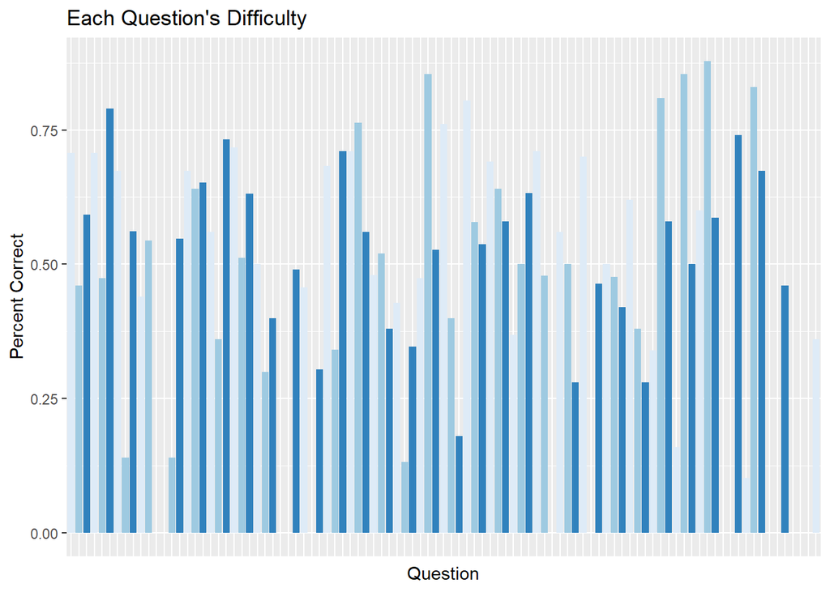

```r
#Total Percent Correct For Each Question
total_percent_correct <- data.frame(percent_correct = c(rep(NA,97)))

temp_total<- c()
for(i in seq(from = 50, to = 4850,by = 50)){
  temp_total[i] <- mean((correct_total_vector == clean_no_dup_tidy$Response)[(i-49):i],na.rm=TRUE)
}


temp_total<- temp_total[!(is.na(temp_total) & !is.nan(temp_total))]

total_percent_correct$percent_correct <- temp_total

#Now we have a dataframe for the percent correct for each question
total_percent_correct <- total_percent_correct %>% mutate(Question = unique(clean_no_dup_tidy$Question))

#Bar Plot revealing question difficulty
library(RColorBrewer)

colourCount = length(unique(clean_no_dup_tidy$Question))
getPalette = colorRampPalette(brewer.pal(9, "Blues"))


ggplot(data = total_percent_correct, aes(x = Question, y = percent_correct, fill = Question)) + geom_bar(stat='identity', position = "dodge")+theme(legend.position = "none")+theme(axis.title.x=element_text(),
        axis.text.x=element_blank(),
        axis.ticks.x=element_blank()) + ylab(label="Percent Correct") + ggtitle("Each Question's Difficulty")+
  scale_fill_manual(values = rep(c('#deebf7','#9ecae1','#3182bd'), 33, drop = FALSE))
```

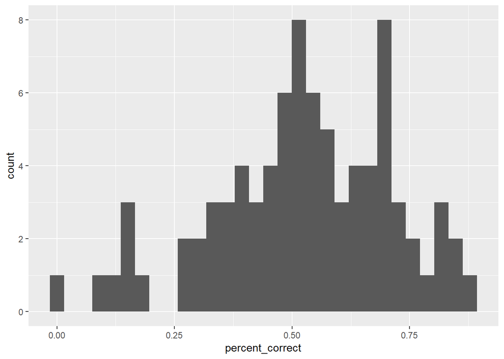

```r
#Histogram of Question Difficulty
ggplot(data = total_percent_correct, aes(x=percent_correct)) + geom_histogram()
```

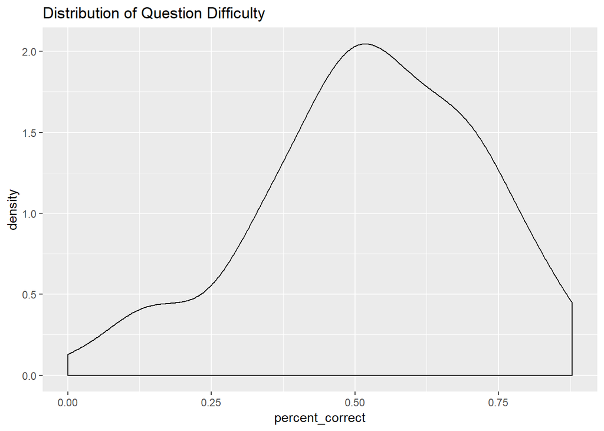

```r
#Density Plot of Question Difficulty
ggplot(data = total_percent_correct, aes(x=percent_correct)) + geom_density()+ ggtitle("Distribution of Question Difficulty")
```

```r
##Summary Stats by Question

mean(total_percent_correct$percent_correct,na.rm=TRUE)
```

[1] 0.5253363

```r
sd(total_percent_correct$percent_correct,na.rm=TRUE)
```

[1] 0.1905528

```r
summary(total_percent_correct$percent_correct,na.rm=TRUE)
```

Min. 1st Qu. Median Mean 3rd Qu. Max. NA’s 0.0000 0.4150 0.5315 0.5253 0.6739 0.8780 13

```r
kable(stargazer(total_percent_correct[1,]))
```

[output not shown]

```r
stargazer(total_percent_correct[1,])
```

Now, we will look at the total data with respective to grouping by student

```r
#SUBSET EXAMPLE #########################################################

#Percent Correct Overall from Question Arrangement
mean(correct_total_vector == clean_no_dup_tidy$Response, na.rm = TRUE)
```

[1] 0.5186744

```r
clean_no_dup_student <- clean_no_dup_tidy %>% arrange(researchID)

correct_total_vector2 <- rep(NA,4850)

correct_total_vector2[which( clean_no_dup_student$Question %>% str_extract(pattern = "A") == "A")] <- "A"

correct_total_vector2[which( clean_no_dup_student$Question %>% str_extract(pattern = "B") == "B")] <- "B"

correct_total_vector2[which( clean_no_dup_student$Question %>% str_extract(pattern = "C") == "C")] <- "C"

correct_total_vector2[which( clean_no_dup_student$Question %>% str_extract(pattern = "D") == "D")] <- "D"

correct_total_vector2[which( clean_no_dup_student$Question %>% str_extract(pattern = "_E") == "_E")] <- "E"

correct_total_vector2[which( clean_no_dup_student$Question %>% str_extract(pattern = "yE") == "yE")] <- "E"



#Percent Correct Overall from Student arrangement check YES
mean(correct_total_vector2 == clean_no_dup_student$Response, na.rm = TRUE)
```

[1] 0.5186744

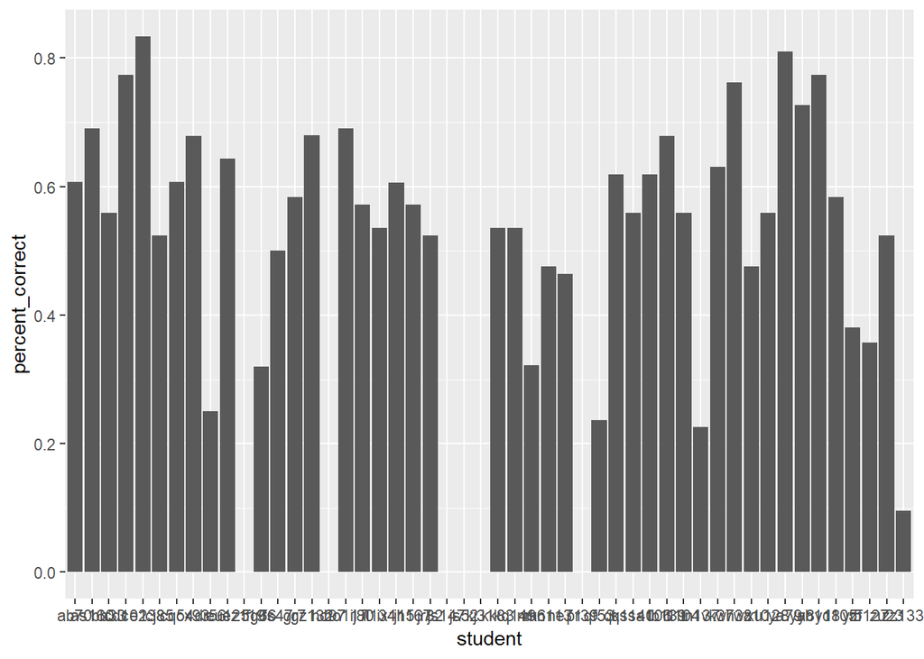

```r
#New Student every 16 rows, 47 students total


temp_total_student<- c()
for(i in seq(from = 97, to = 4850,by = 97)){
  temp_total_student[i] <- mean((correct_total_vector2 == clean_no_dup_student$Response)[(i-96):i],na.rm=TRUE)
}

percent_correct_student_total<-data.frame(percent_correct=c(rep(NA,50)),student=unique(clean_no_dup_student$researchID))

percent_correct_student_total$percent_correct<- temp_total_student[c(which(!is.na(temp_total_student)), which(is.nan(temp_total_student)))[order(c(which(!is.na(temp_total_student)), which(is.nan(temp_total_student))))]]


#percent_correct_student is correct by checking the first student (correct_vector2 == session2.1_tidy_student$Response)[1:16]


#Bar plot revealing student level
ggplot(data = percent_correct_student_total, aes(x = student, y = percent_correct)) + geom_bar(stat='identity', position = position_dodge(width = 200))
```

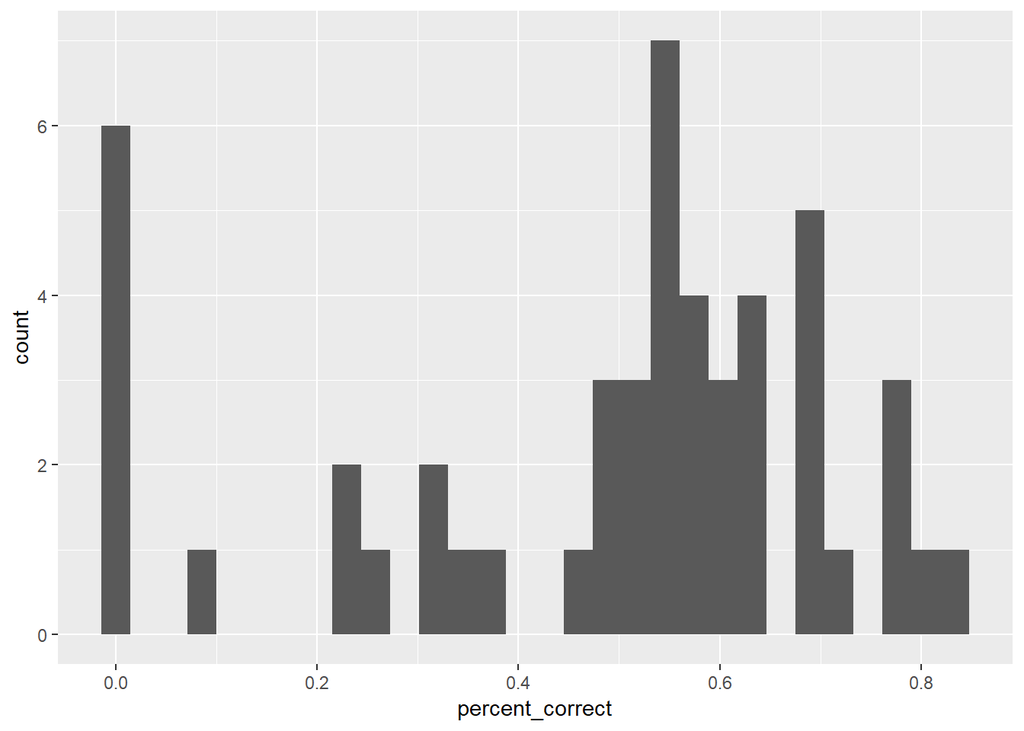

```r
#Histogram of Student Levels
ggplot(data = percent_correct_student_total, aes(x=percent_correct)) + geom_histogram()
```

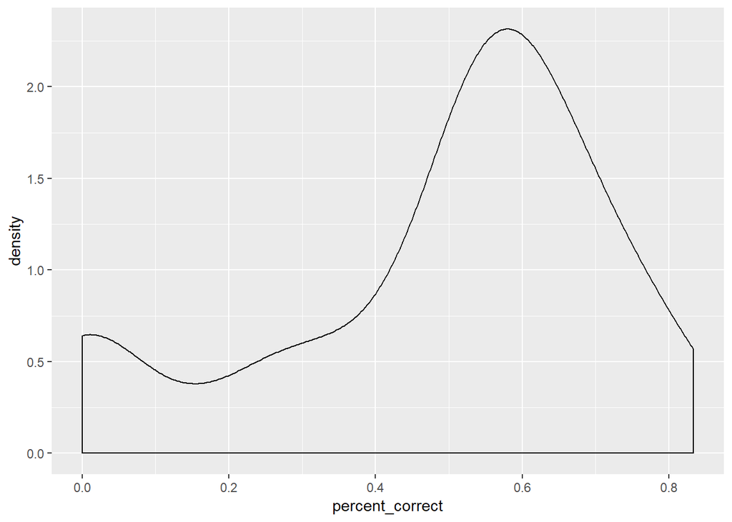

```r
#Density Plot of Student Levels
ggplot(data = percent_correct_student_total, aes(x=percent_correct)) + geom_density()
```

```r
mean(percent_correct_student_total$percent_correct)
```

[1] 0.4851522

```r
sd(percent_correct_student_total$percent_correct)
```

[1] 0.2369275

```r
summary(percent_correct_student_total$percent_correct)
```

Min. 1st Qu. Median Mean 3rd Qu. Max. 0.0000 0.3629 0.5595 0.4852 0.6280 0.8333

AGNES cluster analysis - Aglomerrative Nesting - similar to K-means

Knot testing: Indicator variables: Chapter on splines

spaghetti plots in r

Transition Matrixes on repeated questions

Correspondence Analysis Exploration

```r
#Package FactoMineR
#clean_no_dup2 is the dataset with all questions as variables and count of NVs column


library(FactoMineR)
library(factoextra)
```

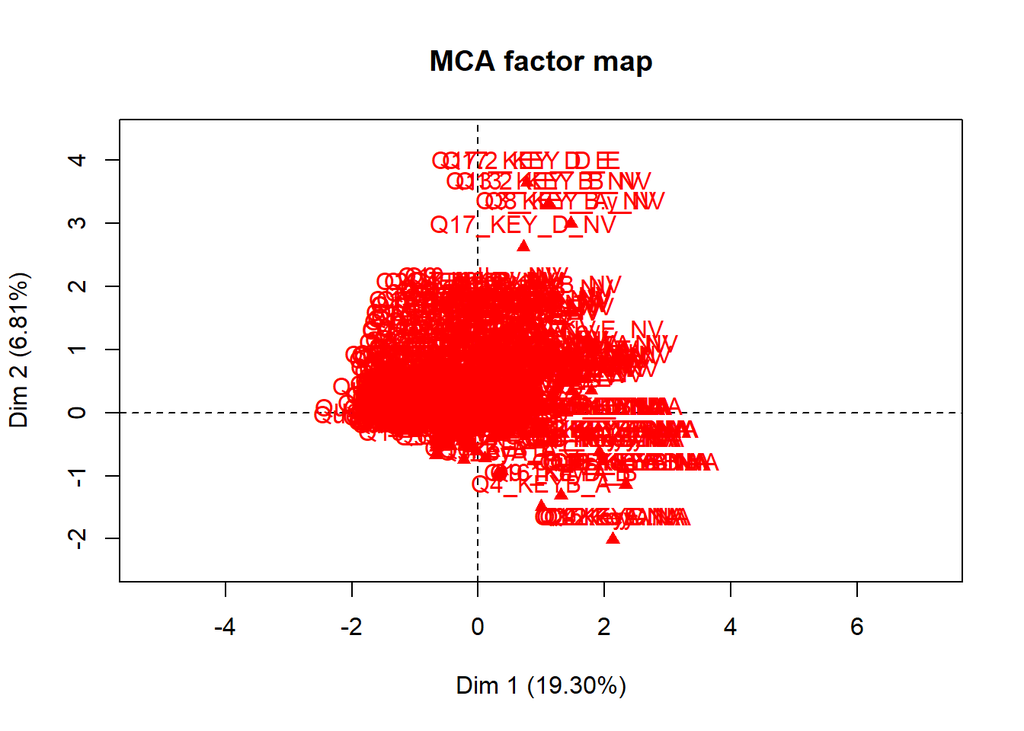

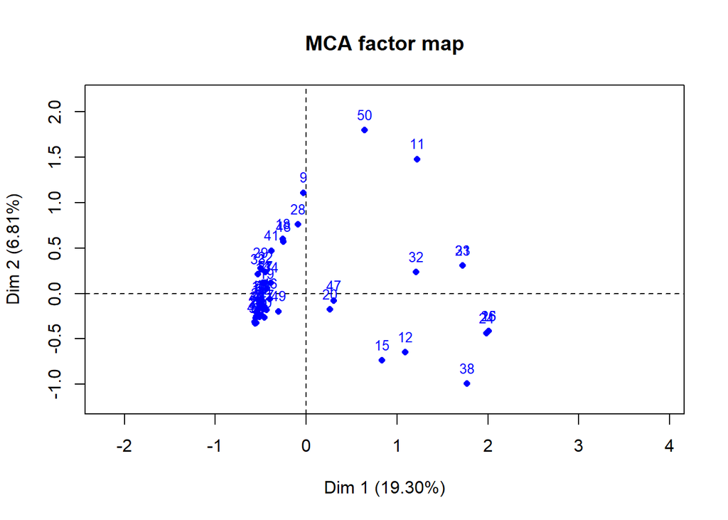

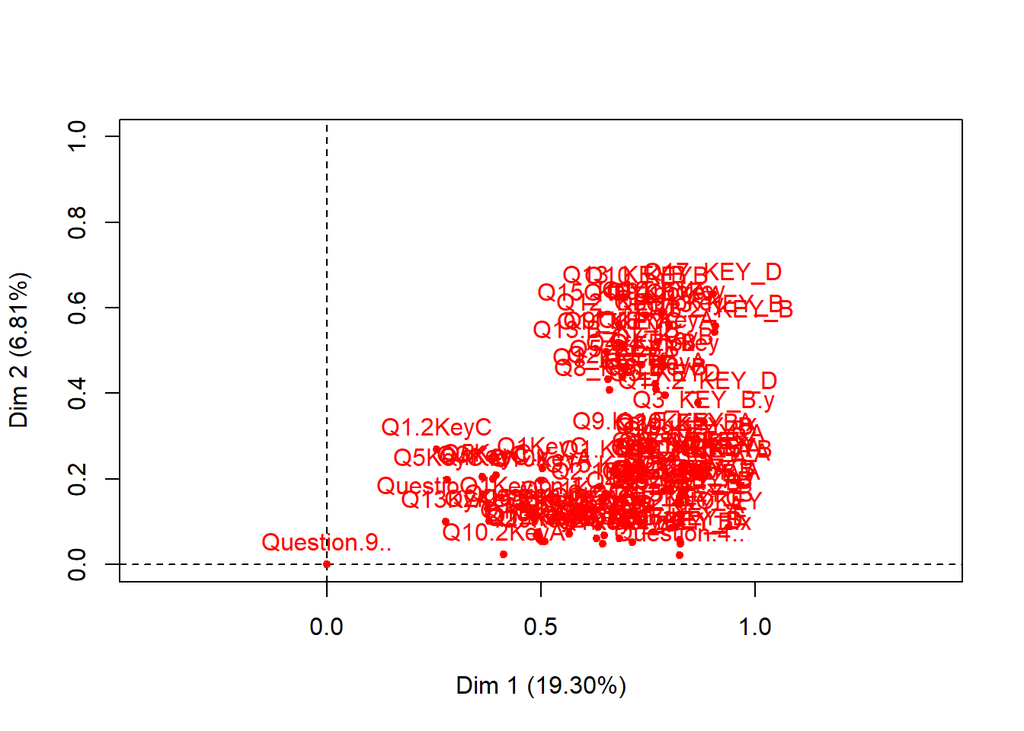

```r
res<- MCA(clean_no_dup[,c(-1,-2)])
```

```r
summary(res)
```

```
##
## Call:
## MCA(X = clean_no_dup[, c(-1, -2)])
##
##
## Eigenvalues
##                        Dim.1   Dim.2   Dim.3   Dim.4   Dim.5   Dim.6
## Variance               0.692   0.244   0.158   0.134   0.131   0.121
## % of var.             19.302   6.815   4.395   3.738   3.660   3.379
## Cumulative % of var.  19.302  26.117  30.512  34.250  37.911  41.290
##                        Dim.7   Dim.8   Dim.9  Dim.10  Dim.11  Dim.12
## Variance               0.114   0.105   0.099   0.098   0.091   0.086
## % of var.              3.174   2.919   2.773   2.745   2.550   2.394
## Cumulative % of var.  44.464  47.383  50.156  52.900  55.450  57.844
##                       Dim.13  Dim.14  Dim.15  Dim.16  Dim.17  Dim.18
## Variance               0.080   0.076   0.074   0.071   0.067   0.066
## % of var.              2.239   2.128   2.058   1.991   1.881   1.842
## Cumulative % of var.  60.082  62.210  64.268  66.259  68.139  69.981
##                       Dim.19  Dim.20  Dim.21  Dim.22  Dim.23  Dim.24
## Variance               0.064   0.062   0.061   0.055   0.054   0.052
## % of var.              1.795   1.716   1.694   1.533   1.502   1.439
## Cumulative % of var.  71.776  73.492  75.186  76.719  78.220  79.660
##                       Dim.25  Dim.26  Dim.27  Dim.28  Dim.29  Dim.30
## Variance               0.051   0.048   0.047   0.044   0.043   0.042
## % of var.              1.413   1.338   1.317   1.236   1.191   1.163
## Cumulative % of var.  81.072  82.410  83.727  84.963  86.154  87.317
##                       Dim.31  Dim.32  Dim.33  Dim.34  Dim.35  Dim.36
## Variance               0.041   0.039   0.038   0.036   0.033   0.032
## % of var.              1.151   1.084   1.068   1.012   0.930   0.889
## Cumulative % of var.  88.467  89.552  90.620  91.632  92.561  93.451
##                       Dim.37  Dim.38  Dim.39  Dim.40  Dim.41  Dim.42
## Variance               0.032   0.029   0.028   0.026   0.025   0.023
## % of var.              0.885   0.816   0.781   0.711   0.689   0.650
## Cumulative % of var.  94.335  95.151  95.933  96.643  97.332  97.982
##                       Dim.43  Dim.44  Dim.45  Dim.46  Dim.47  Dim.48
## Variance               0.021   0.018   0.016   0.015   0.001   0.000
## % of var.              0.593   0.509   0.451   0.428   0.037   0.000
## Cumulative % of var.  98.575  99.083  99.534  99.963 100.000 100.000
##                       Dim.49
## Variance               0.000
```

[output cut: 48 more lines]

```
## Q2_KEY_D_D   0.178  0.083  0.021  1.019 |
## Q2_KEY_D_NV -0.107  0.021  0.004 -0.467 |
##
## Categorical variables (eta2)
##                Dim.1 Dim.2 Dim.3
## Q1_KEY_B     | 0.825 0.052 0.043 |
## Q2_KEY_D     | 0.826 0.049 0.029 |
## Q3_KEY_B.x   | 0.825 0.049 0.036 |
## Question.4.. | 0.824 0.022 0.007 |
## Q1_KEY_C     | 0.825 0.104 0.609 |
## Q2_KEY_B.x   | 0.838 0.279 0.539 |
## Q2.2_KEY_B   | 0.826 0.144 0.419 |
## Q4_KEY_B     | 0.837 0.264 0.555 |
## Q4.2_KEY_B   | 0.831 0.170 0.334 |
## Q4.3_KEY_B   | 0.828 0.114 0.324 |
```

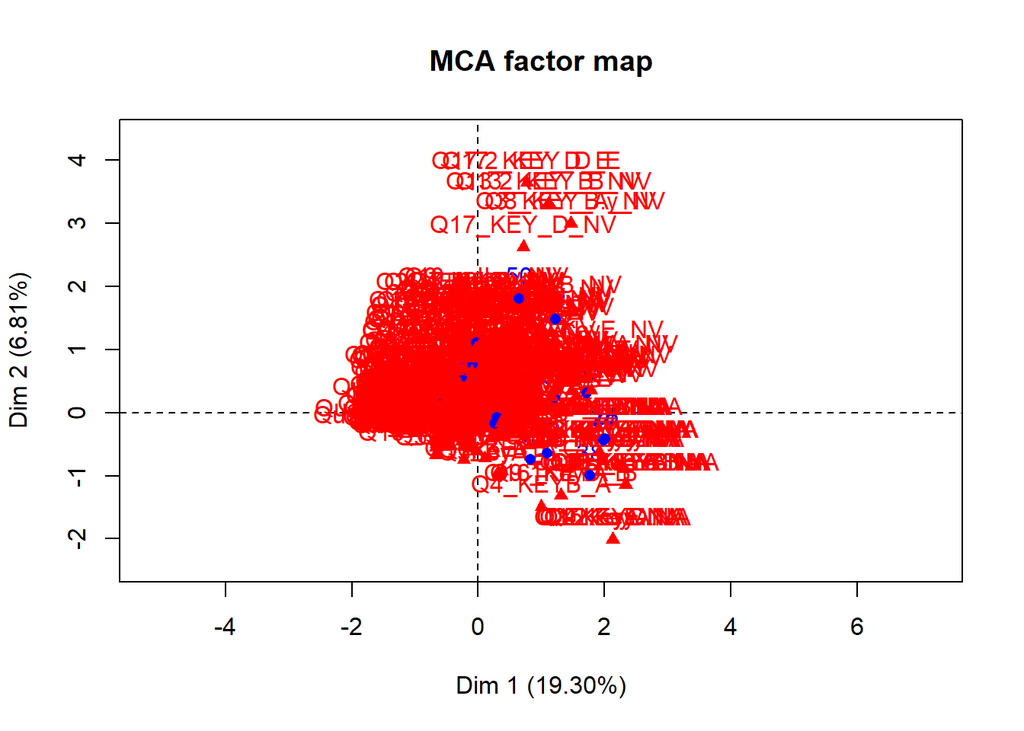

```r
plot(res)
```

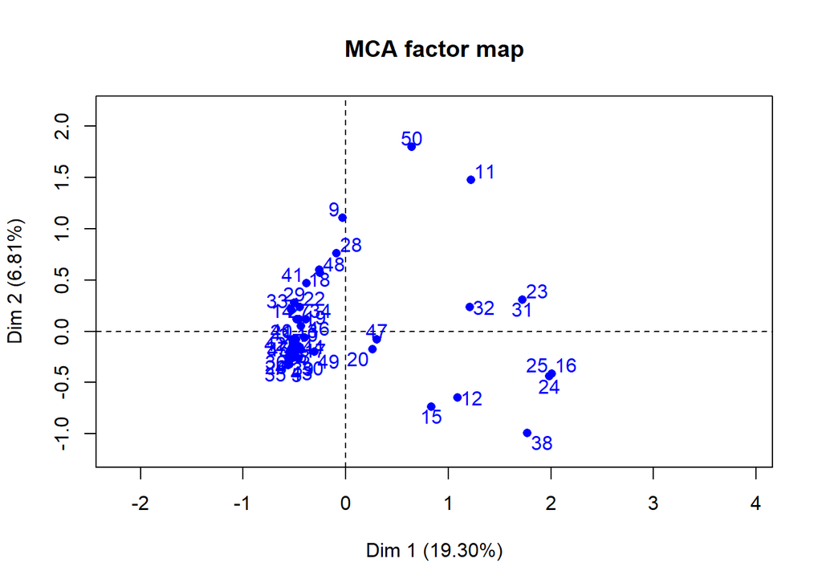

```r
plot(res, invisible = c("var"),autoLab = "y")
```

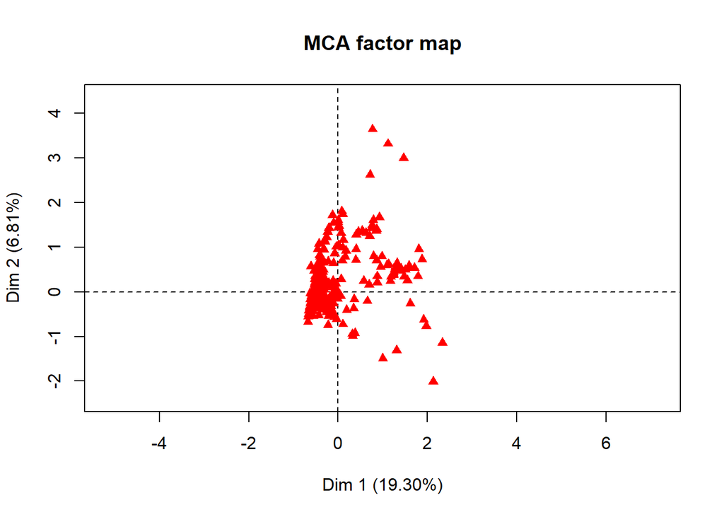

```r
plot(res, invisible = c("ind"),label="none")
```

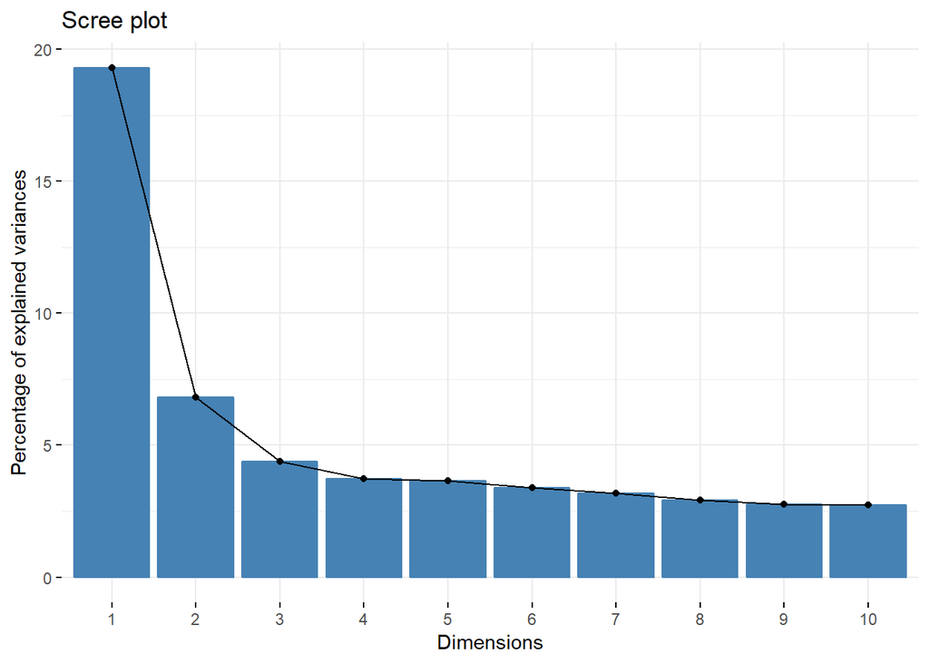

```r
fviz_screeplot(res)
```

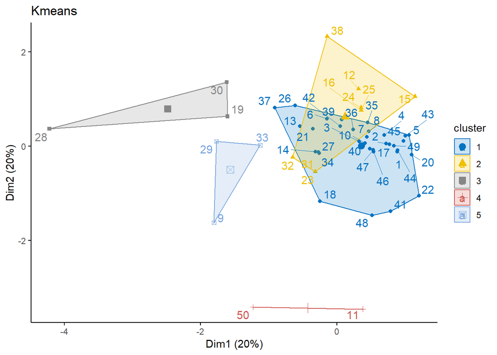

```r
#Gives coordinates for the individual students of the first 5 dimensions from MCA
km<- data.frame(res$ind$coord)

groupes.kmeans<- kmeans(km,centers = 5,nstart =5)

fviz_cluster(groupes.kmeans, data = km, palette = "jco", repel= TRUE, main = "Kmeans", ggtheme = theme_classic())
```

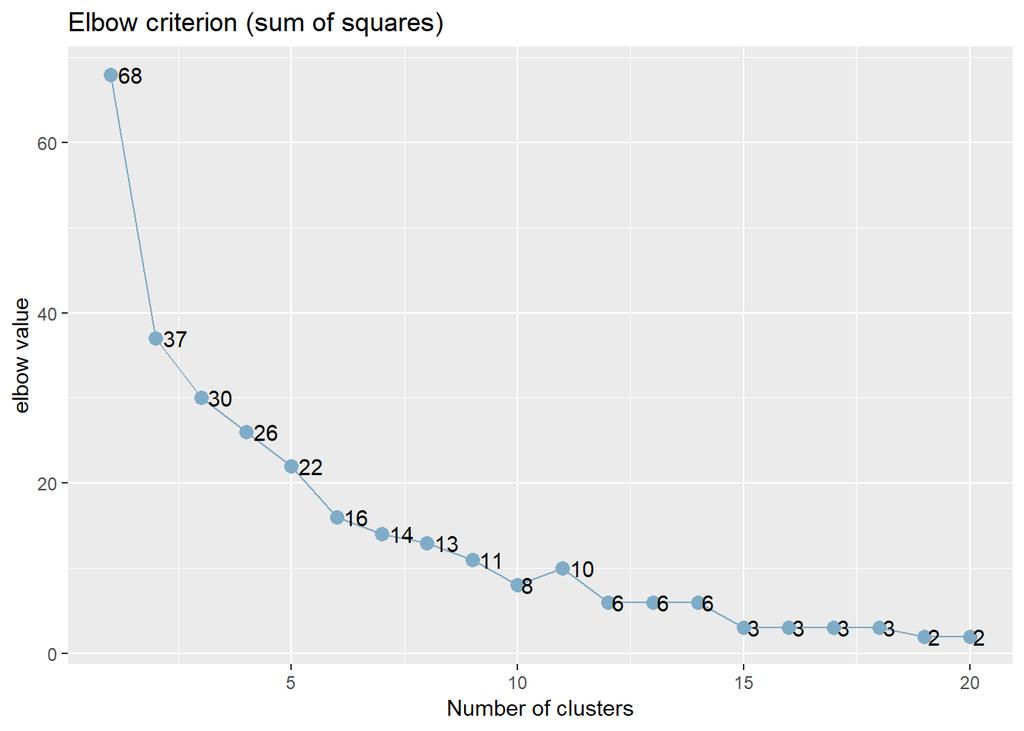

```
## geom_path: Each group consists of only one observation. Do you need to
## adjust the group aesthetic?
```

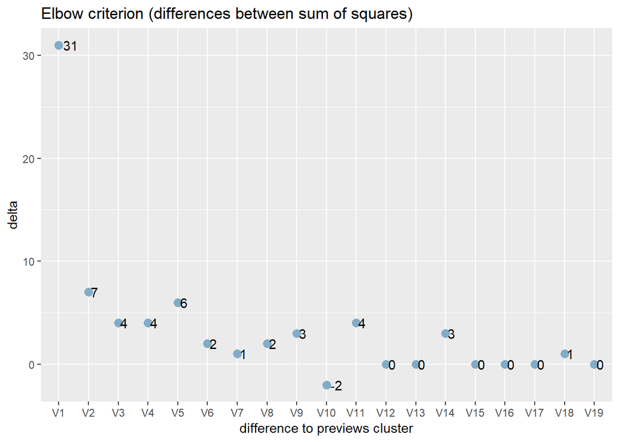

```r
library(sjPlot)

sjc.elbow(km,steps=20,show.diff = T)
```

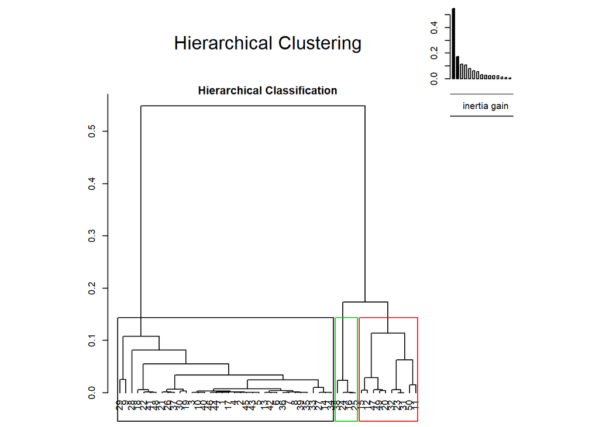

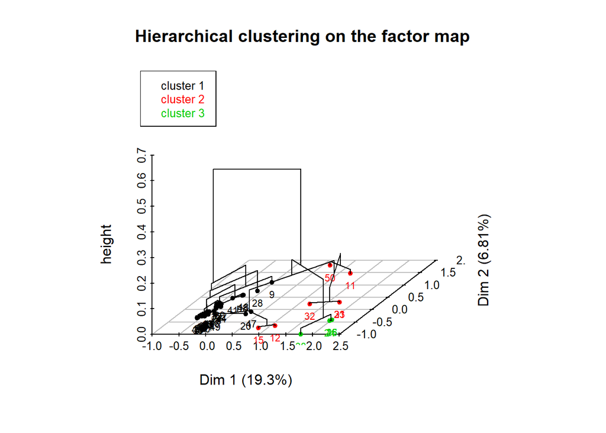

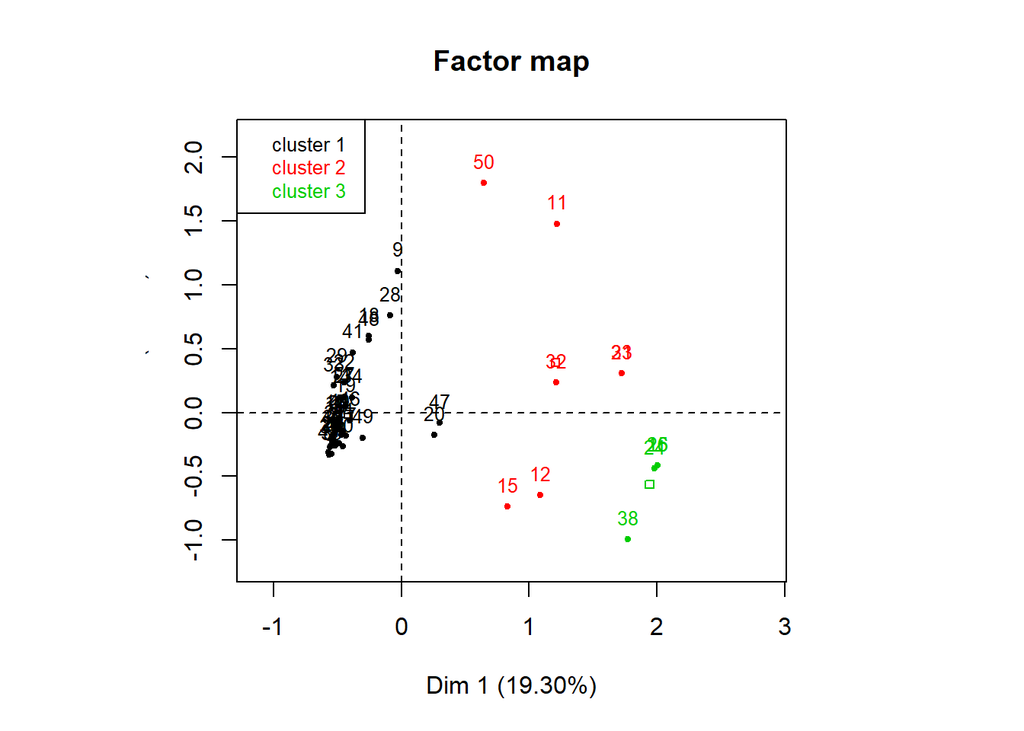

```r
hier<- HCPC(res,nb.clust=-1)
```

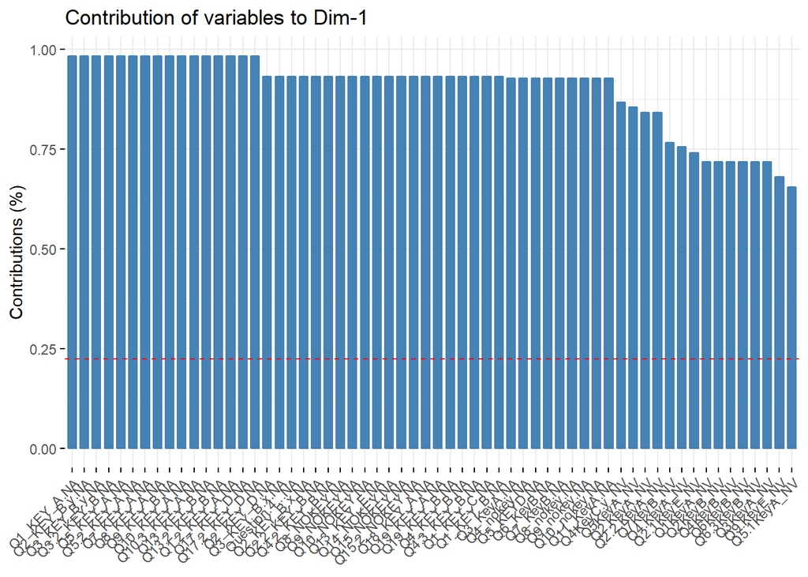

```r
plot(hier, choice=c("3D.map, tree, bar"))


# Total contribution to dimension 1 and 2
fviz_contrib(res, choice = "var", axes = 1, top = 60)
```

[figure not shown]

```r
fviz_mca_var(res, col.var = "contrib",
             gradient.cols = c("#00AFBB", "#E7B800", "#FC4E07"),
             repel = TRUE, # avoid text overlapping (slow)
             ggtheme = theme_minimal()
             )
```

```r
var <- get_mca_var(res)

#The 16 Questions with the highest contribution to dimension 1
#They all have the same contribution -- why?

library(stringr)

most_contribution <- head(sort(var$contrib[,1], decreasing = TRUE),16)

most_contribution<- unlist(strsplit(names(most_contribution), split = ".NA"))
```

```r
#All The Questions That were Repeated
#index 34 is Q1.2_KEY_A, goes with #21 but was not seen among other questions, index 77 is Q1.2KeyC, goes with 92

Repeated_Questions <- clean_no_dup_student$Question[c(6:7,8:10,16:17,23:24,25:26,30:31,32:33,35:36,56:57,61:62,67:68,70:71,74:75,82:83,85:87,89:90,93:94, 21,34, 77, 92)]

#Proportion of Repeated Qestions in Total
length(Repeated_Questions)/nrow(total_percent_correct)
```

```
## [1] 0.4123711
```

```r
#Proportion of Repeated QUestions in Most Contribution
mean(most_contribution %in% Repeated_Questions)
```

```
## [1] 0.75
```

```r
#A Big Difference -- tells us that the variation can be mostly contributed to the repeated questions
```

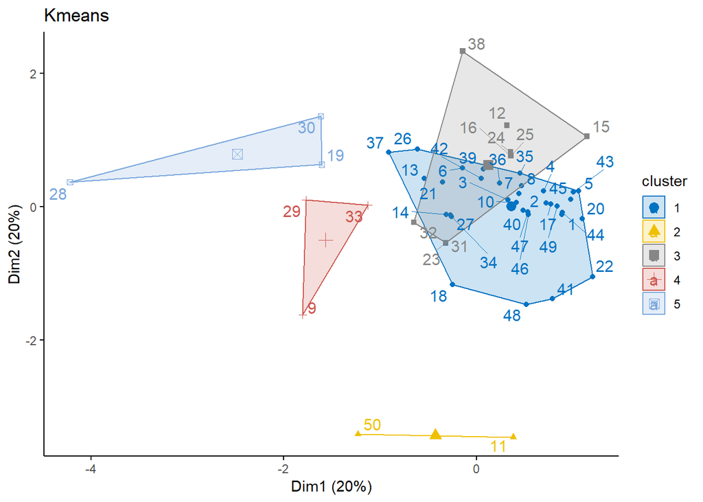

```r
#Trying CA function instread of MCA for FactoMineRlibrary(FactoMineR)
library(factoextra)


#res<- CA(clean_no_dup[,c(-1,-2)])

#summary(res)

#plot(res)
#plot(res, invisible = c("var"),autoLab = "y")
#plot(res, invisible = c("ind"),label="none")


#fviz_screeplot(res)

#Gives coordinates for the individual students of the first 5 dimensions from MCA
km<- data.frame(res$ind$coord)

groupes.kmeans<- kmeans(km,centers = 5,nstart =5)

fviz_cluster(groupes.kmeans, data = km, palette = "jco", repel= TRUE, main = "Kmeans", ggtheme = theme_classic())
```

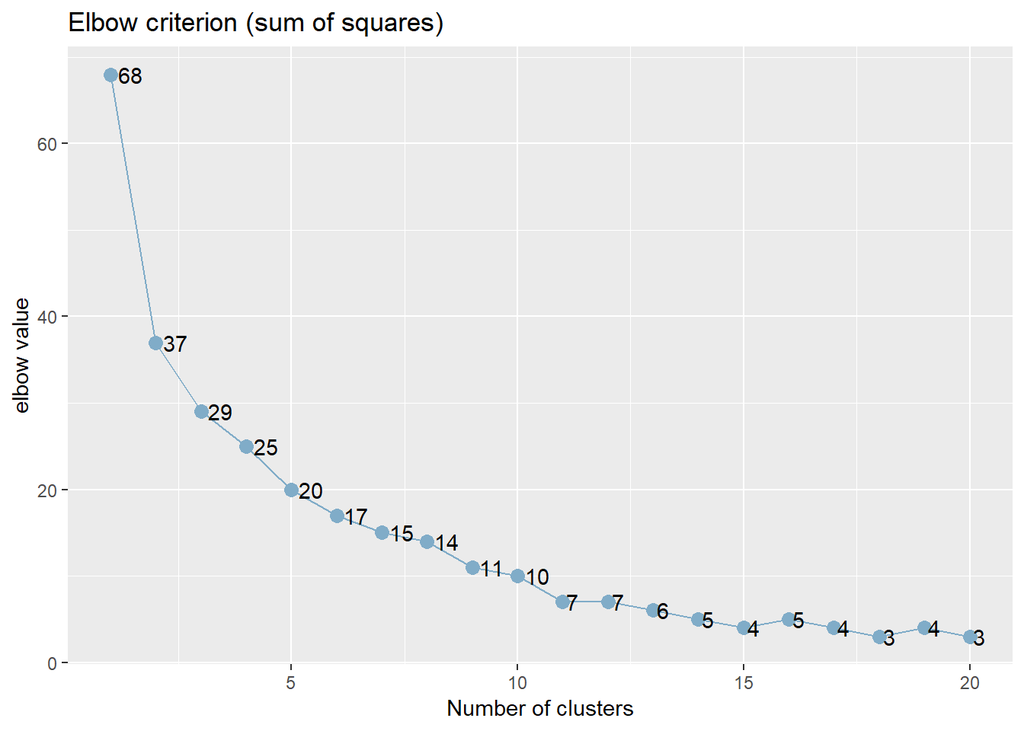

```
## geom_path: Each group consists of only one observation. Do you need to
## adjust the group aesthetic?
```

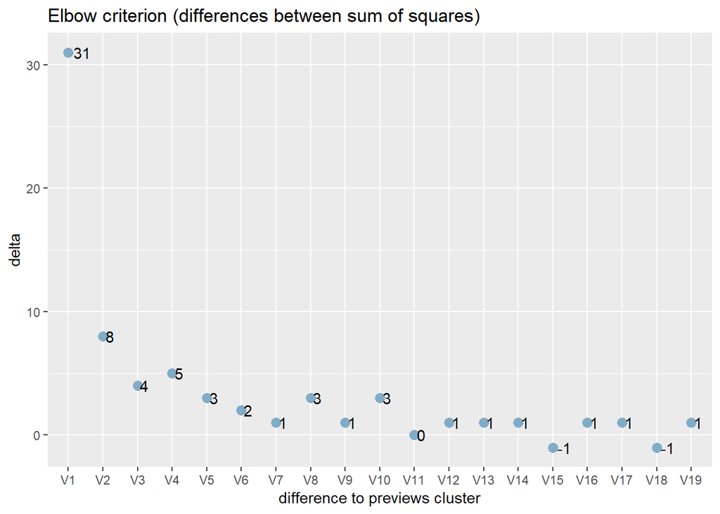

```r
library(sjPlot)

sjc.elbow(km,steps=20,show.diff = T)
```

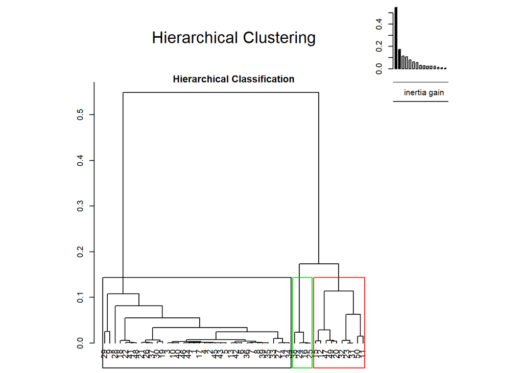

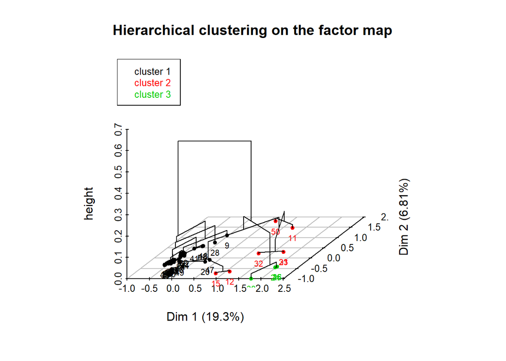

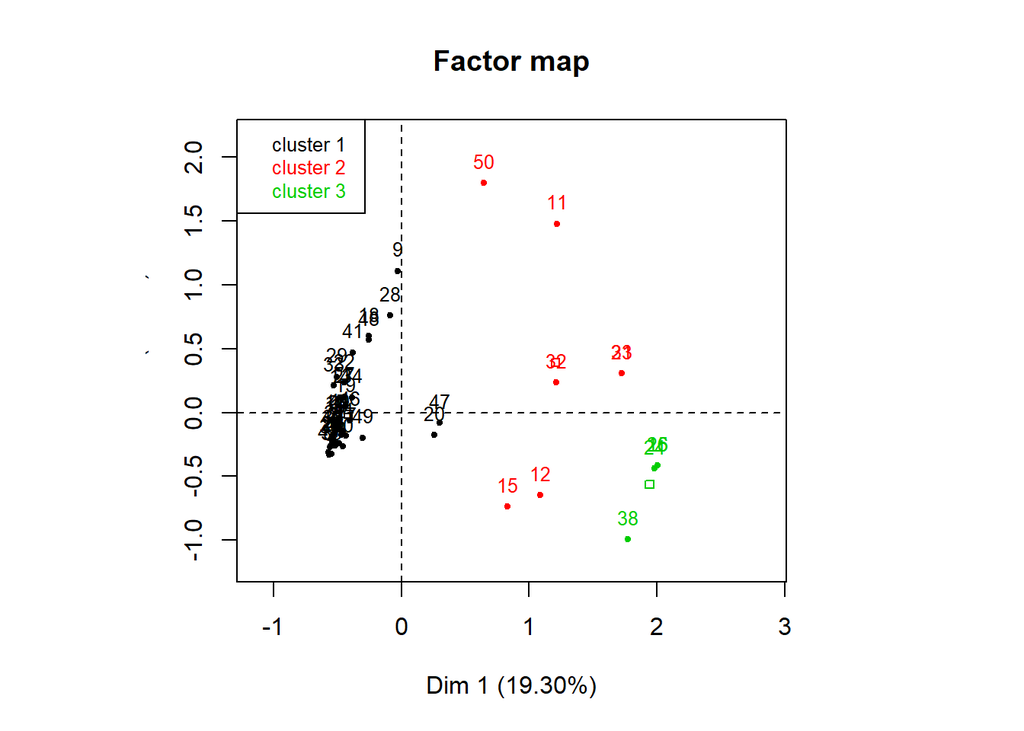

```r
hier<- HCPC(res,nb.clust=-1)
```

```r
plot(hier, choice=c("3D.map, tree, bar"))
```

```r
library(dplyr)

hierarchal_cluster <- data.frame(student = clean_no_dup[,1])

hierarchal_cluster
```

```
##    student
## 1     ab70
## 2    as160
## 3     bb33
## 4    cd102
## 5    ce138
## 6     cj85
## 7     cq54
## 8     cx93
## 9     dr56
## 10   eu125
## 11   ez119
## 12    fg66
## 13    fs47
## 14     gr7
```

[output cut: 36 more lines]

```r
hierarchal_cluster<- cbind(hierarchal_cluster, cluster = hier$data.clust[,"clust"])


correct_cluster <- full_join(percent_correct_student_total, hierarchal_cluster, by = 'student')


mean_correct_clust <-correct_cluster %>% group_by(cluster) %>% summarise(mean_correct = mean(percent_correct))

mean_correct_clust
```

```
## # A tibble: 3 x 2
##   cluster mean_correct
##   <fct>          <dbl>
## 1 1             0.582
## 2 2             0.190
## 3 3             0.0565
```

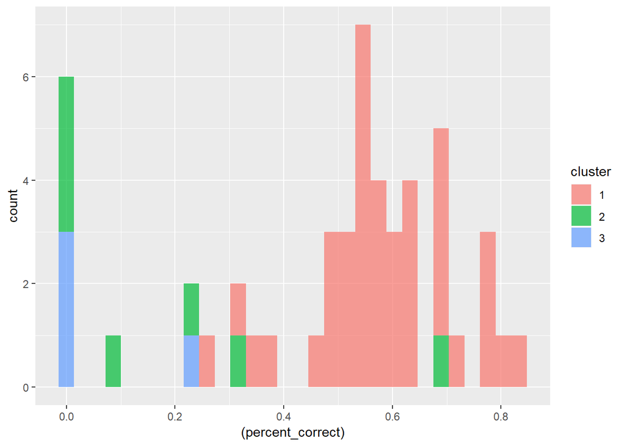

```r
#Create histograms facet_wrap by ggplot

ggplot(correct_cluster,aes(x=(percent_correct), fill=cluster)) + geom_histogram(stat="bin", alpha = 0.7)
```

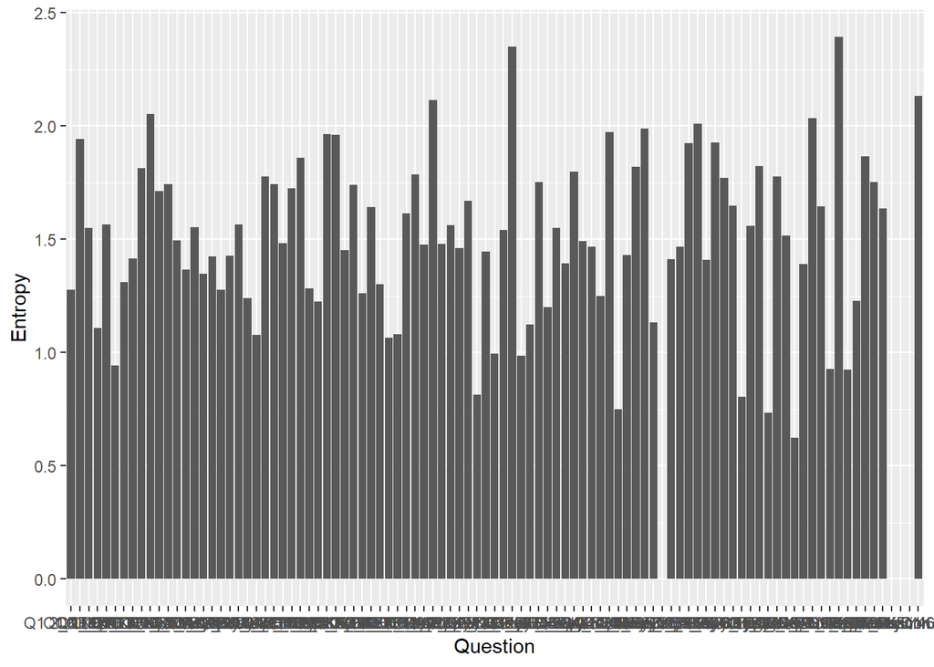

```r
#Now, let's look at the correlations between the clusters


#Shannon's Entropy - Information thoery
library(DescTools)
#Entropy()
#MutInf()


Entropy_Q_vector<- numeric(length(3:99))

for(i in 3:ncol(clean_no_dup)){
  Entropy_Q_vector[i-2] <- Entropy(table(clean_no_dup[,i]))
}


Entropy_Q_df <- data.frame(Entropy = Entropy_Q_vector, Question = names(clean_no_dup)[3:99])


ggplot(Entropy_Q_df,aes(x = Question, y = Entropy)) + geom_bar(stat = 'identity')
```

```r
#Stat summary for Entropy of All Q's
summary(Entropy_Q_vector)
```

```
##    Min. 1st Qu.  Median    Mean 3rd Qu.    Max.
##   0.000   1.251   1.483   1.449   1.754   2.394
```

```r
#Stat Summary for Entropy of Repeated Q's
Entropy_Rep_Q <- Entropy_Q_df %>% filter(Question %in% Repeated_Questions)
summary(Entropy_Rep_Q[,1])
```

```
##    Min. 1st Qu.  Median    Mean 3rd Qu.    Max.
##   0.000   1.274   1.515   1.513   1.773   2.350
```

```r
#Stat Summary for Entropy of Most Contrib to Dim 1
Entropy_Most_Cont_Q <- Entropy_Q_df %>% filter(Question %in% most_contribution)
summary(Entropy_Most_Cont_Q[,1])
```

```
##    Min. 1st Qu.  Median    Mean 3rd Qu.    Max.
##  0.0000  0.8974  1.2509  1.2140  1.6706  2.0536
```

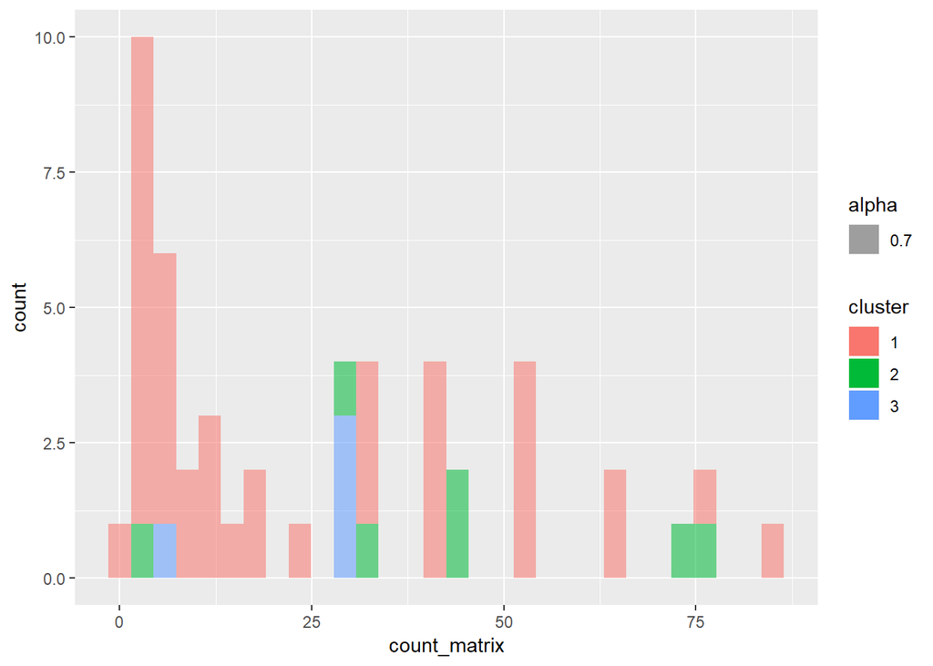

```r
#Start by seeing how many questions they actually answered -- look at number of NV's

clean_clust <- full_join(clean_no_dup, hierarchal_cluster, by = c("researchID"= "student"))

ggplot(clean_clust, aes(count_matrix, fill = cluster, alpha = 0.7)) + geom_histogram()
```

```r
#Next, look at the actual correlations between each other: 1 for same answers, 0 for different answers



#Look up if there is an easy way to measure correlations between categorical variables
#Cramer's V Derived from the Chi-Squared Test of Independence of Categorical Variables -- We are interested in students as the variables

#DO == to rowwise() of clean_clust and compute the mean as a measure of "correlation" between students
```

```r
library(ca)

#ca from ca package example
data("author")
ca(author)
```

```
##
##  Principal inertias (eigenvalues):
##            1        2        3        4        5        6        7
## Value      0.007664 0.003688 0.002411 0.001383 0.001002 0.000723 0.000659
## Percentage 40.91%   19.69%   12.87%   7.38%    5.35%    3.86%    3.52%
##            8        9        10       11
## Value      0.000455 0.000374 0.000263 0.000113
## Percentage 2.43%    2%       1.4%     0.6%
##
##
##  Rows:
##         three daughters (buck) drifters (michener) lost world (clark)
## Mass                  0.085407            0.079728           0.084881
## ChiDist               0.097831            0.094815           0.128432
## Inertia               0.000817            0.000717           0.001400
## Dim. 1               -0.095388            0.405697           1.157803
## Dim. 2               -0.794999           -0.405560          -0.023114
##         east wind (buck) farewell to arms (hemingway)
## Mass            0.089411                     0.082215
## ChiDist         0.118655                     0.122889
## Inertia         0.001259                     0.001242
## Dim. 1         -0.173901                    -0.831886
## Dim. 2          0.434443                    -0.136485
##         sound and fury 7 (faulkner) sound and fury 6 (faulkner)
## Mass                       0.082310                    0.083338
## ChiDist                    0.172918                    0.141937
## Inertia                    0.002461                    0.001679
## Dim. 1                     0.302025                   -0.925572
## Dim. 2                     2.707599                    0.966944
##         profiles of future (clark) islands (hemingway) pendorric 3 (holt)
## Mass                      0.089722            0.082776           0.079501
## ChiDist                   0.187358            0.165529           0.113174
## Inertia                   0.003150            0.002268           0.001018
## Dim. 1                    1.924060           -1.566481          -0.724758
## Dim. 2                   -0.249310           -1.185338          -0.106349
##         asia (michener) pendorric 2 (holt)
## Mass           0.077827           0.082884
## ChiDist        0.155115           0.101369
## Inertia        0.001873           0.000852
## Dim. 1         1.179548          -0.764937
```

[output cut: 13 more lines]

```
## Inertia  0.000491  0.001555 0.000522 0.000134  0.000808  0.000618 0.000651
## Dim. 1  -1.020713 -1.501277 0.267473 0.453341 -2.755177  1.018257 0.712695
## Dim. 2   0.353017 -0.302413 0.889546 0.916032  1.231557 -0.165020 1.400966
##                 n         o         p         q         r        s
## Mass     0.068968  0.076572  0.015159  0.000669  0.051897 0.060660
## ChiDist  0.075706  0.088101  0.250617  0.582298  0.111725 0.123217
## Inertia  0.000395  0.000594  0.000952  0.000227  0.000648 0.000921
## Dim. 1  -0.200364 -0.108491  1.610807  4.079786  0.591372 0.860202
## Dim. 2  -0.417258  0.637987 -1.837948 -1.914791 -0.734216 0.405610
##                 t        u        v         w        x        y         z
## Mass     0.093010 0.029756 0.009612  0.025847 0.001160 0.021902  0.000801
## ChiDist  0.050630 0.119215 0.269770  0.232868 0.600831 0.301376  0.833700
## Inertia  0.000238 0.000423 0.000700  0.001402 0.000419 0.001989  0.000557
## Dim. 1  -0.100464 0.163295 2.281333 -2.499232 3.340505 0.001519  6.808100
## Dim. 2   0.203141 1.017140 0.177022 -0.284722 4.215355 4.706083 -3.509223
```

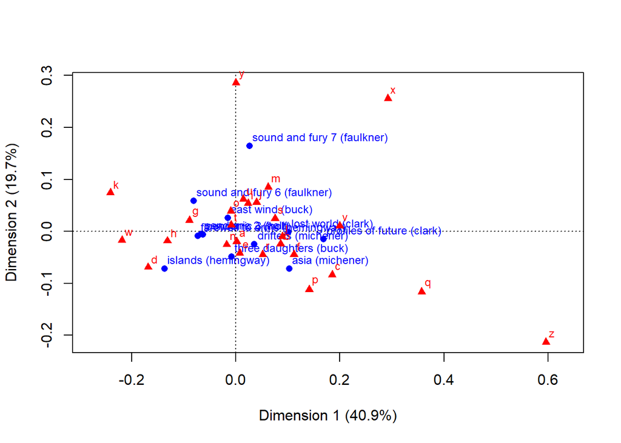

```r
plot(ca(author))
```

```r
#Example from documentation for CA
data(children)
res.ca <- CA (children, row.sup = 15:18, col.sup = 6:8)
```

[figure not shown]